# SCN2A from the BDSM tutorior book

## Lee Sang Yoon (2016270905)

# Exercise

## 3.1. For-loops and Vectorization

### Here we examine more details of genetic mutations as to their functional consequence and position of SCN2A mutations. In the dataset includes, there are two columns called c.DNA and p.Protein, containing the cDNA or protein position for the genetic mutations.

### During these exercises, we will look at the concept of for-loop and vectorization, which you learn from the Chapter 3.4. Let’s look at the column p.Protein. It contains protein positions from each patient. What would you check at the first place?

#### Task 1

#### Task 2

#### Task 3

```r
setwd("C:/Users/user/Documents/R_project/bsms222_905_lee")
library(rio)

d = rio::import('https://www.ncbi.nlm.nih.gov/pmc/articles/PMC6015533/bin/NIHMS957592-supplement-1.xlsx')

library(dslabs)
library(tidyverse)
```

```r
library(NHANES)
library(readxl)
library(dplyr)
library(stringr)
library(splitstackshape)
library(ggpubr)
library(ggplot2)
library(data.table)
library(purrr)
library(readr)
library(readxl)
library(viridis)
library(MetBrewer)
library(rtracklayer)
library(RColorBrewer)
library(BiocManager)
library(rtracklayer)
```

### Let’s write down your code to explore this column.

```r
head(d$p.Protein)
```

```
## [1] "." "." "." "." "." "."
```

### If you need more information on SCN2A, please visit the Uniprot description for SCN2A. The Uniprot database contains description for protein domains.

### Then, I would remove the characters from the string so we can have only numerics for positions. Here I use gsub function to extract numbers from string. Let’s remove non-numeric characters from the string.

```r
gsub('[^0-9]', '', 'p.R102X')
```

```
## [1] "102"
```

### In the dataset, we have many rows for protein positions. One way we might try is to set up for-loop to process each row.

```r
for (i in 1:293) {
  a <- gsub('[^0-9]', '', d[i, 'p.Protein'] )
}
```

### Do you think this is an effective approach? As we have done in your assignment, for-loop is not a good choice to process vectors because R can do vectorization for this process with a shorter and clearer code. So this mean you can apply gsub on vector and return your output to another column (could be new assign).

### Please write a code to do vectorization

```r
i<- 1:293
d$p.Protein1<- gsub('[^0-9]', '', d[i, 'p.Protein'] )
```

## 3.2. Counting the recurrent mutations

### Recurrent mutations are the ones that the same genetic mutations occur in multiple individuals. Recurrent mutations can be common 1) when the mutation does not affect on natural selection, 2) when the mutation is beneficial, 3) in the hotspot for a disease or strongly associated with trait. However, given we are dealing with the genetic mutations from rare disorders, the mutations in the dataset are supposed to be uniquely present in general population. Otherwise, the recurrent mutations can indicate strong association with the phenotype.

### To assess the recurrent mutations, the first thing we can try is to examine whether the same mutations occur in multiple individuals. Since the dataset contains individual patients for each row, we can simply check the frequency using:

```r
c <- as.data.frame(table(d$p.Protein))
```

### or we can check the number of unique variants in the dataset by:

### Please write your code

```r
filter(c, Freq==1)
```

| Var1 | Freq |
| --- | --- |
| p.A1310S | 1 |
| p.A1500T | 1 |
| p.A1652P | 1 |
| p.A1773T | 1 |
| p.A202V | 1 |
| p.A240S | 1 |
| p.A263T | 1 |
| p.A733T | 1 |
| p.A812V | 1 |
| p.A880S | 1 |

[output cut: 153 more lines]

```r
count(filter(c, Freq==1))
```

| n |
| --- |
| 163 |

### How many unique variants you can find? and which variants are occurred in multiple times?

### Then, you can use other columns to check frequency for different groups. Which columns you would use for more grouping?

If you find that, please check the recurrent mutations for each group.

### Please write your code

```r
f <- as.data.frame(table(d$c.DNA))

filter(f, Freq==1)
```

| Var1 | Freq |
| --- | --- |
| c.1028A>G | 1 |
| c.1094C>T | 1 |
| c.1165C>T | 1 |
| c.1270G>T | 1 |
| c.1288G>C | 1 |
| c.1289A>C | 1 |
| c.1289A>G | 1 |
| c.1316CTGAACAGAAGGAAGCTGAATTTCAGCAGATGC>C | 1 |
| c.1317_1348del | 1 |
| c.1317T>TC | 1 |

[output cut: 166 more lines]

```r
count(filter(f, Freq==1))
```

| n |
| --- |
| 176 |

## 3.3. What is the proportion of diagnosis for SCN2A patient?

### SCN2A mutation can have multiple different consequences for disease phenotypes. It can cause ASD but also other neurodevelopmental conditions. In total cases, how many phenotypes occur in SCN2A patients. Then, calculate the proportion of the phenotypes among total cases.

### Please write your code

```r
#1
g<- prop.table(table(d$Classification))

h<- as.data.frame(g)
```

```r
#2
q <- as.data.frame(table(d$Classification))

q
```

| Var1 | Freq |
| --- | --- |
| ASD/DD | 92 |
| BIS | 36 |
| IEE | 111 |
| IEE_Mild/Ataxia | 7 |
| Other | 3 |
| Schizophrenia | 5 |
| Unclear | 39 |

```r
sum(q$Freq)
```

```
## [1] 293
```

```r
q<- mutate(q, proportion= q$Freq/sum(q$Freq))
```

### Then, you might be intrigued to whether females and males have different occurrence in each disorder. Let’s check it.

### Please write your code

```r
d1<- d[d$PatientSex=="M", ]
d2<- d[d$PatientSex=="F", ]

e1 <- as.data.frame(table(d1$Classification))
mutate(e1, proportion= e1$Freq/sum(e1$Freq))
```

| Var1 | Freq | proportion |
| --- | --- | --- |
| ASD/DD | 44 | 0.369747899 |
| BIS | 12 | 0.100840336 |
| IEE | 43 | 0.361344538 |
| IEE_Mild/Ataxia | 4 | 0.033613445 |
| Other | 1 | 0.008403361 |
| Unclear | 15 | 0.126050420 |

```r
e2 <- as.data.frame(table(d2$Classification))
mutate(e2, proportion= e2$Freq/sum(e2$Freq))
```

| Var1 | Freq | proportion |
| --- | --- | --- |
| ASD/DD | 26 | 0.22807018 |
| BIS | 11 | 0.09649123 |
| IEE | 57 | 0.50000000 |
| IEE_Mild/Ataxia | 3 | 0.02631579 |
| Other | 2 | 0.01754386 |
| Schizophrenia | 1 | 0.00877193 |
| Unclear | 14 | 0.12280702 |

### Another question you can ask is whether different mutation consequences occur in each phenotype. Let’s find out how many mutation consequences are observed in each phenotype.

### Please write your code

```r
d3<- select(d, c("c.DNA" , "Classification"))

filter(d3, Classification=='ASD/DD')
```

| c.DNA | Classification |
| --- | --- |
| . | ASD/DD |
| . | ASD/DD |
| . | ASD/DD |
| . | ASD/DD |
| c.34G>A | ASD/DD |
| c.82C>T | ASD/DD |
| c.228G>CCC | ASD/DD |
| c.245A>G | ASD/DD |
| c.304C>T | ASD/DD |
| c.304C>T | ASD/DD |

[output cut: 82 more lines]

```r
filter(d3, Classification=='BIS')
```

| c.DNA | Classification |
| --- | --- |
| . | BIS |
| c.106A>G | BIS |
| c.106A>G | BIS |
| c.562C>T | BIS |
| c.605C>T | BIS |
| c.620T>C | BIS |
| c.623T>A | BIS |
| c.668G>A | BIS |
| c.718G>T | BIS |
| c.754A>G | BIS |

[output cut: 26 more lines]

```r
filter(d3, Classification=='IEE')
```

| c.DNA | Classification |
| --- | --- |
| . | IEE |
| . | IEE |
| c.396T>A | IEE |
| c.408G>T | IEE |
| c.408G>T | IEE |
| c.506A>G | IEE |
| c.632G>A | IEE |
| c.632G>A | IEE |
| c.634A>G | IEE |
| c.638T>A | IEE |

[output cut: 101 more lines]

```r
filter(d3, Classification=='IEE_Mild/Ataxia')
```

| c.DNA | Classification |
| --- | --- |
| . | IEE_Mild/Ataxia |
| c.788C>T | IEE_Mild/Ataxia |
| c.788C>T | IEE_Mild/Ataxia |
| c.2783T>G | IEE_Mild/Ataxia |
| c.4565G>C | IEE_Mild/Ataxia |
| c.5644C>G | IEE_Mild/Ataxia |
| c.5644C>G | IEE_Mild/Ataxia |

```r
filter(d3, Classification=='Other')
```

| c.DNA | Classification |
| --- | --- |
| c.514A>G | Other |
| c.982T>G | Other |
| c.982T>G | Other |

```r
filter(d3, Classification=='Unclear')
```

| c.DNA | Classification |
| --- | --- |
| c.106A>G | Unclear |
| c.562C>T | Unclear |
| c.710T>A | Unclear |
| c.773G>C | Unclear |
| c.788C>T | Unclear |
| c.796G>T | Unclear |
| c.1165C>T | Unclear |
| c.1434TGGG>TGG | Unclear |
| c.1840C>T | Unclear |
| c.2315A>G | Unclear |

[output cut: 29 more lines]

## 3.4. Find the position where different consequences of mutations occur

### If you checked the recurrent mutations, you might want to find a locus where two or more variants occur. Such loci might indicate functionally important position of the gene and you might find some insight as to a cause of disease.

### Please write your code

```r
d4<- select(d, c("c.DNA" , "TrueRecurrence"))
filter(d4, TrueRecurrence>2)
```

| c.DNA | TrueRecurrence |
| --- | --- |
| c.788C>T | 6 |
| c.788C>T | 6 |
| c.788C>T | 6 |
| c.788C>T | 6 |
| c.788C>T | 6 |
| c.788C>T | 6 |
| c.788C>T | 6 |
| c.788C>T | 6 |
| c.2558G>A | 7 |
| c.2558G>A | 7 |

[output cut: 33 more lines]

## 3.5. Sketch a plot to visualize your analysis

### When you examine the dataset, you would draw something to show your output. Though we haven’t learnt how to plot data yet, we can have a quick sketch for the dataset. There’s no restriction on your suggestion. Please submit your hand-drawing for the plot you would like to show from this dataset.

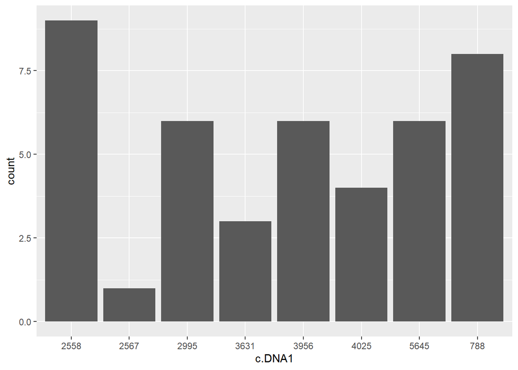

```r
d4<- select(d, c("c.DNA" , "TrueRecurrence"))
d5<- mutate(d4, c.DNA1= gsub('[^0-9]', '', d4$c.DNA))
d6<- filter(d5, TrueRecurrence>2)

d6|>
  arrange(c.DNA1)|>
  ggplot(aes(c.DNA1))+ geom_bar()
```